# Tarefa 2 - Preparação de Dados

Leonardo Martelli e Marcello Fabrizio

24/10/2021

### 0 - Limpeza do ambiente e carregamento de pacotes

```r
rm(list=ls())

library('ggplot2')
library('gridExtra')
library('GGally')
library(grid)
library(stringr)
library(corrplot)
library(caret)
library(ggfortify)
```

### 1 - Carregue a base de dados e mostre a estrutura do dataset (str()). O arquivo do dataset não pode ser modificado de forma alguma. A leitura deverá tratar qualquer característica do arquivo.

```r
beans_data = read.csv("Dry_Bean_Dataset.csv",header=T, sep=";", na.strings="?", dec=",")
str(beans_data)
```

```
## 'data.frame':    13611 obs. of  17 variables:
##  $ Area           : int  28395 28734 29380 30008 30140 30279 30477 30519 30685 30834 ...
##  $ Perimeter      : num  610 638 624 646 620 ...
##  $ MajorAxisLength: num  208 201 213 211 202 ...
##  $ MinorAxisLength: num  174 183 176 183 190 ...
##  $ AspectRation   : num  1.2 1.1 1.21 1.15 1.06 ...
##  $ Eccentricity   : num  0.55 0.412 0.563 0.499 0.334 ...
##  $ ConvexArea     : int  28715 29172 29690 30724 30417 30600 30970 30847 31044 31120 ...
##  $ EquivDiameter  : num  190 191 193 195 196 ...
##  $ Extent         : num  0.764 0.784 0.778 0.783 0.773 ...
##  $ Solidity       : num  0.989 0.985 0.99 0.977 0.991 ...
##  $ roundness      : num  0.958 0.887 0.948 0.904 0.985 ...
##  $ Compactness    : num  0.913 0.954 0.909 0.928 0.971 ...
##  $ ShapeFactor1   : num  0.00733 0.00698 0.00724 0.00702 0.0067 ...
##  $ ShapeFactor2   : num  0.00315 0.00356 0.00305 0.00321 0.00366 ...
##  $ ShapeFactor3   : num  0.834 0.91 0.826 0.862 0.942 ...
##  $ ShapeFactor4   : num  0.999 0.998 0.999 0.994 0.999 ...
##  $ Class          : chr  "SEKER" "SEKER" "SEKER" "SEKER" ...
```

### 2 - Altere a variável do tipo do feijão (Class) para um factor.

```r
class_factor = factor(beans_data$Class)
beans_data$Class = class_factor
```

### 3 - Plote um gráfico de barras que ilustre as quantidades de cada classe.

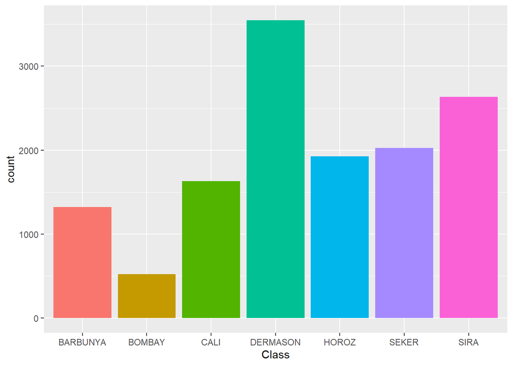

```r
ggplot(beans_data, aes(Class, fill = Class)) + geom_bar() + theme(legend.position = "none")
```

### 4 - Realize a normalização dos dados via Z-score. Plote um boxplot para ilustrar a distribuição de cada variável. Mostre as estatísticas de cada variável (summary).

```r
normalized_data = preProcess(beans_data, method=c("center", "scale"))

beans_data = predict(normalized_data, beans_data)
summary(beans_data)
```

```
##       Area           Perimeter       MajorAxisLength   MinorAxisLength
##  Min.   :-1.1127   Min.   :-1.5425   Min.   :-1.5933   Min.   :-1.7736
##  1st Qu.:-0.5702   1st Qu.:-0.7082   1st Qu.:-0.7800   1st Qu.:-0.5876
##  Median :-0.2863   Median :-0.2816   Median :-0.2714   Median :-0.2188
##  Mean   : 0.0000   Mean   : 0.0000   Mean   : 0.0000   Mean   : 0.0000
##  3rd Qu.: 0.2825   3rd Qu.: 0.5690   3rd Qu.: 0.6576   3rd Qu.: 0.3282
##  Max.   : 6.8738   Max.   : 5.2736   Max.   : 4.8862   Max.   : 5.7355
##
##   AspectRation      Eccentricity       ConvexArea      EquivDiameter
##  Min.   :-2.2636   Min.   :-5.7819   Min.   :-1.1111   Min.   :-1.5516
##  1st Qu.:-0.6119   1st Qu.:-0.3801   1st Qu.:-0.5728   1st Qu.:-0.6421
##  Median :-0.1302   Median : 0.1472   Median :-0.2885   Median :-0.2472
##  Mean   : 0.0000   Mean   : 0.0000   Mean   : 0.0000   Mean   : 0.0000
##  3rd Qu.: 0.5021   3rd Qu.: 0.6475   3rd Qu.: 0.2863   3rd Qu.: 0.4458
##  Max.   : 3.4339   Max.   : 1.7448   Max.   : 7.0359   Max.   : 5.3451
##
##      Extent           Solidity          roundness        Compactness
##  Min.   :-3.9607   Min.   :-14.5689   Min.   :-6.4460   Min.   :-2.5811
##  1st Qu.:-0.6336   1st Qu.: -0.3160   1st Qu.:-0.6920   1st Qu.:-0.6059
##  Median : 0.2063   Median :  0.2446   Median : 0.1659   Median : 0.0229
##  Mean   : 0.0000   Mean   :  0.0000   Mean   : 0.0000   Mean   : 0.0000
##  3rd Qu.: 0.7562   3rd Qu.:  0.6159   3rd Qu.: 0.7323   3rd Qu.: 0.5575
##  Max.   : 2.3726   Max.   :  1.6167   Max.   : 1.9725   Max.   : 3.0373
##
##   ShapeFactor1       ShapeFactor2       ShapeFactor3       ShapeFactor4
##  Min.   :-3.35603   Min.   :-1.93292   Min.   :-2.35617   Min.   :-10.8500
##  1st Qu.:-0.58838   1st Qu.:-0.94387   1st Qu.:-0.62863   1st Qu.: -0.3116
##  Median : 0.07231   Median :-0.03762   Median :-0.01562   Median :  0.3029
##  Mean   : 0.00000   Mean   : 0.00000   Mean   : 0.00000   Mean   :  0.0000
##  3rd Qu.: 0.62749   3rd Qu.: 0.76244   3rd Qu.: 0.52948   3rd Qu.:  0.6457
##  Max.   : 3.44642   Max.   : 3.27086   Max.   : 3.34535   Max.   :  1.0693
##
##       Class
##  BARBUNYA:1322
##  BOMBAY  : 522
##  CALI    :1630
##  DERMASON:3546
##  HOROZ   :1928
##  SEKER   :2027
##  SIRA    :2636
```

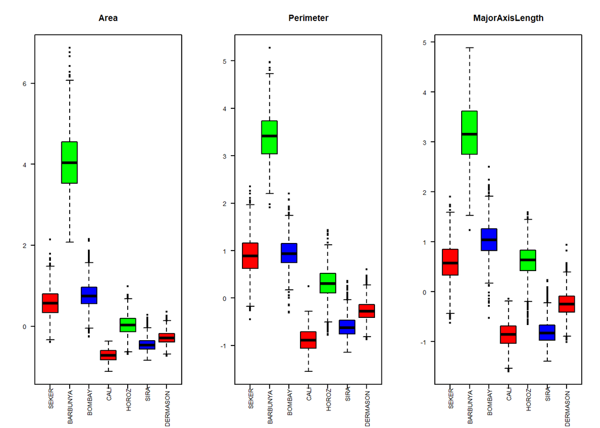

```r
classes = unique(beans_data$Class)
num_classes = length(classes)

colors=c("red", "green", "blue")

par(mfrow=c(1,3), cex=0.5)
for(i in 1:3){
  plot <- boxplot(beans_data[,i] ~ beans_data$Class,
                  col=colors, xlab = "",
                  ylab="",
                  main = names(beans_data)[i],
                  xaxt = "n",
                  yaxt = "n")
  axis(side = 1, labels = FALSE)
  axis(side = 2, las = 2, cex.axis = 0.9, font =20)
  text(x = 1:num_classes,
       labels = classes,
       par("usr")[3],
       xpd = T,
       srt = 90,
       adj = 1.2,
       cex = 0.9)
}
```

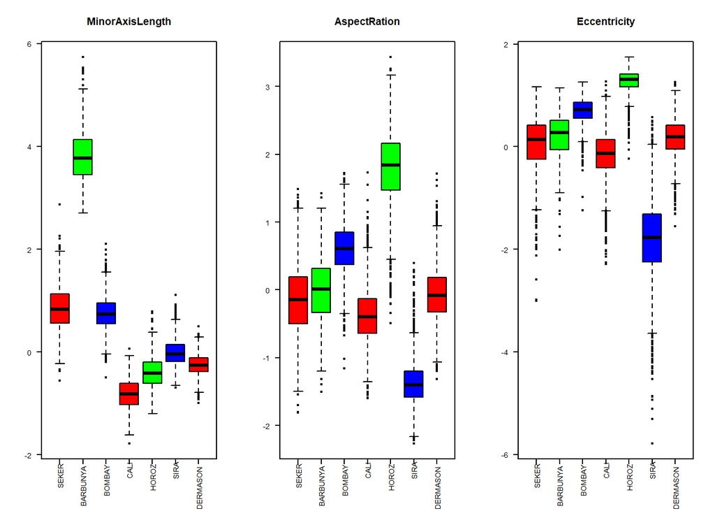

```r
par(mfrow=c(1,3), cex=0.5)
for(i in 4:6){
  plot <- boxplot(beans_data[,i] ~ beans_data$Class,
                  col=colors, xlab = "",
                  ylab="",
                  main = names(beans_data)[i],
                  xaxt = "n",
                  yaxt = "n")
  axis(side = 1, labels = FALSE)
  axis(side = 2, las = 2, cex.axis = 0.9, font =20)
  text(x = 1:num_classes,
       labels = classes,
       par("usr")[3],
       xpd = T,
       srt = 90,
       adj = 1.2,
       cex = 0.9)
}
```

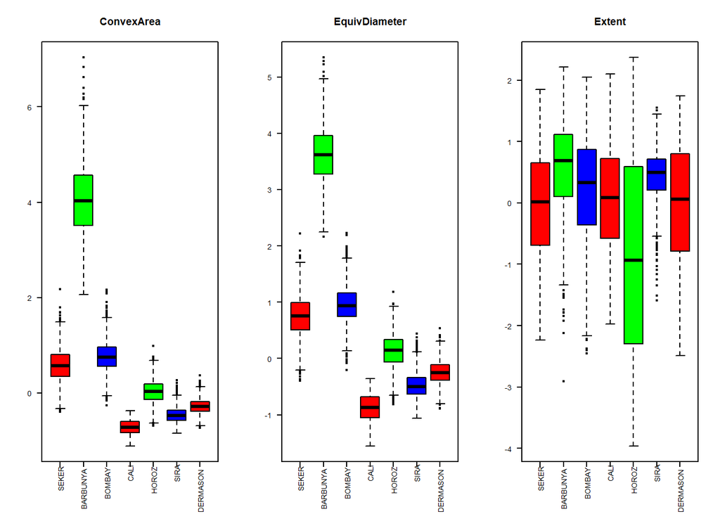

```r
par(mfrow=c(1,3), cex=0.5)
for(i in 7:9){
  plot <- boxplot(beans_data[,i] ~ beans_data$Class,
                  col=colors, xlab = "",
                  ylab="",
                  main = names(beans_data)[i],
                  xaxt = "n",
                  yaxt = "n")
  axis(side = 1, labels = FALSE)
  axis(side = 2, las = 2, cex.axis = 0.9, font =20)
  text(x = 1:num_classes,
       labels = classes,
       par("usr")[3],
       xpd = T,
       srt = 90,
       adj = 1.2,
       cex = 0.9)
}
```

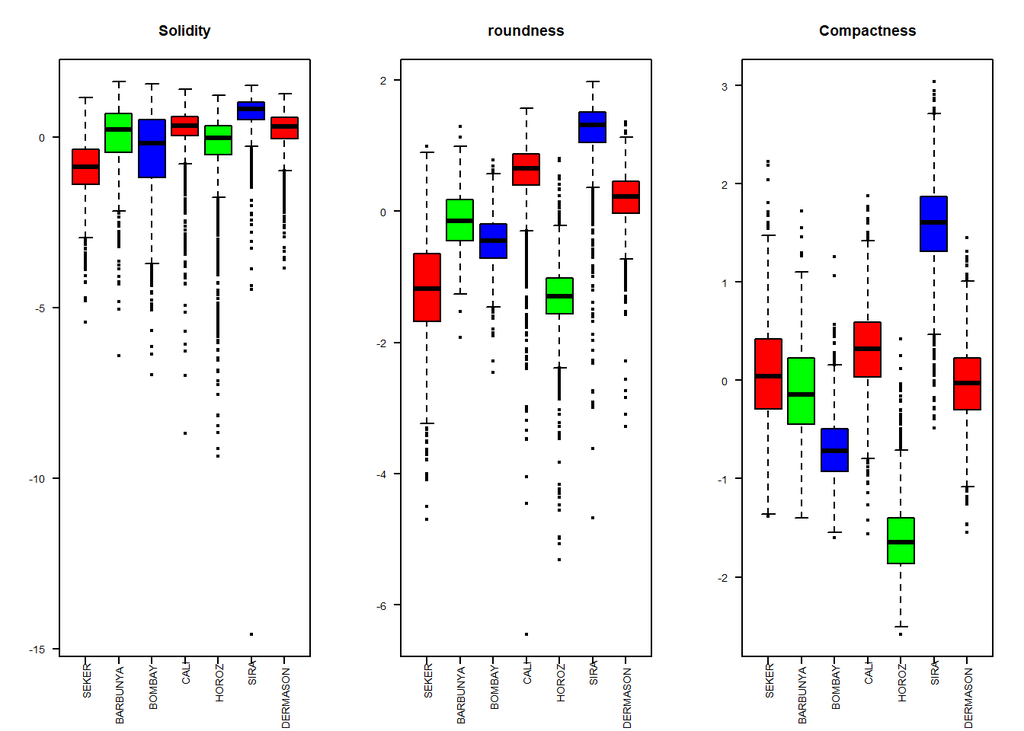

```r
par(mfrow=c(1,3), cex=0.5)
for(i in 10:12){
  plot <- boxplot(beans_data[,i] ~ beans_data$Class,
                  col=colors, xlab = "",
                  ylab="",
                  main = names(beans_data)[i],
                  xaxt = "n",
                  yaxt = "n")
  axis(side = 1, labels = FALSE)
  axis(side = 2, las = 2, cex.axis = 0.9, font =20)
  text(x = 1:num_classes,
       labels = classes,
       par("usr")[3],
       xpd = T,
       srt = 90,
       adj = 1.2,
       cex = 0.9)
}
```

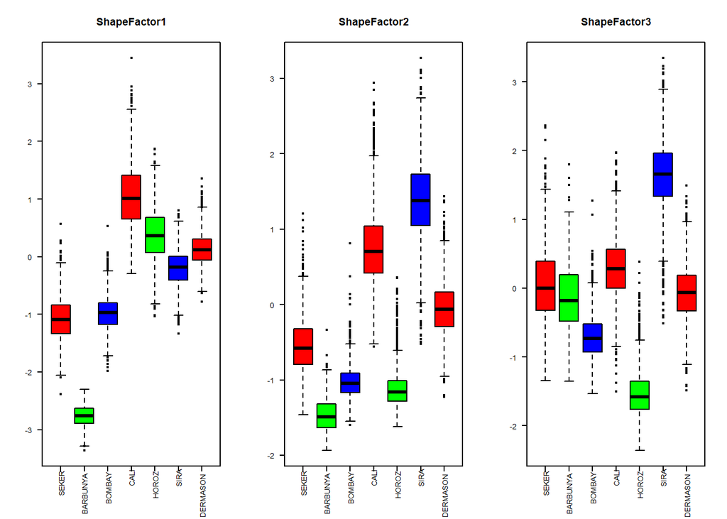

```r
par(mfrow=c(1,3), cex=0.5)
for(i in 13:15){
  plot <- boxplot(beans_data[,i] ~ beans_data$Class,
                  col=colors, xlab = "",
                  ylab="",
                  main = names(beans_data)[i],
                  xaxt = "n",
                  yaxt = "n")
  axis(side = 1, labels = FALSE)
  axis(side = 2, las = 2, cex.axis = 0.9, font =20)
  text(x = 1:num_classes,
       labels = classes,
       par("usr")[3],
       xpd = T,
       srt = 90,
       adj = 1.2,
       cex = 0.9)
}
```

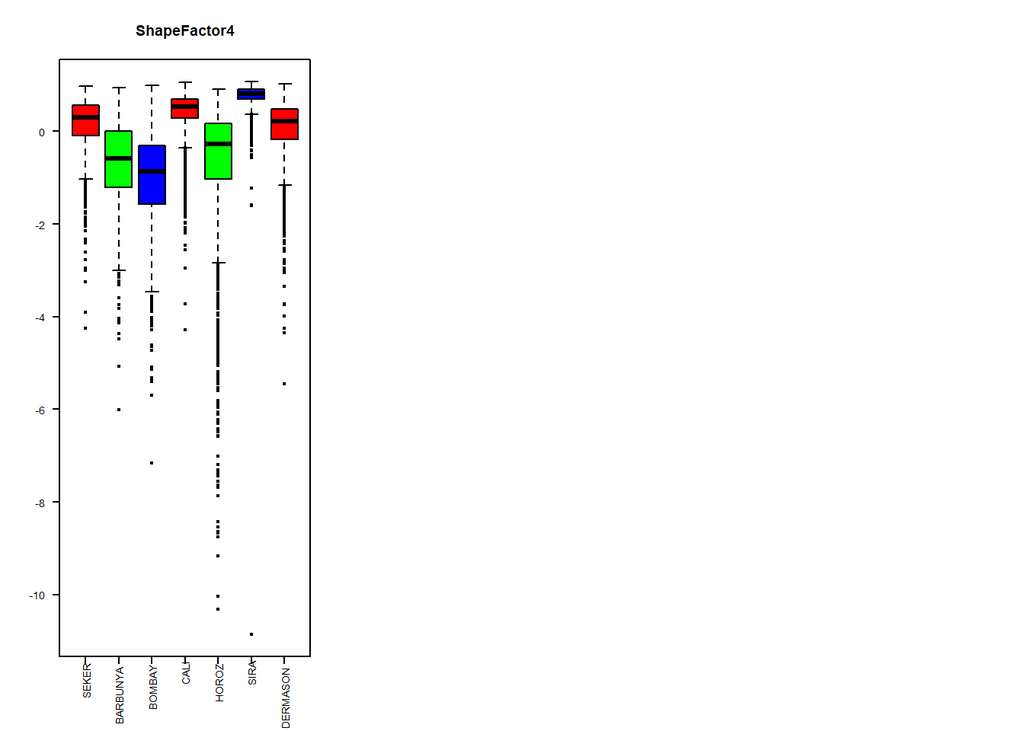

```r
par(mfrow=c(1,3), cex=0.5)
for(i in 16:16){
  plot <- boxplot(beans_data[,i] ~ beans_data$Class,
                  col=colors, xlab = "",
                  ylab="",
                  main = names(beans_data)[i],
                  xaxt = "n",
                  yaxt = "n")
  axis(side = 1, labels = FALSE)
  axis(side = 2, las = 2, cex.axis = 0.9, font =20)
  text(x = 1:num_classes,
       labels = classes,
       par("usr")[3],
       xpd = T,
       srt = 90,
       adj = 1.2,
       cex = 0.9)
}
```

### 5 - Realize a seleção de características (correlação). Plote o gráfico de correlação. Liste as características que foram removidas.

```r
correlation_matrix = cor(beans_data[1:16])

strong_correlations = findCorrelation(correlation_matrix, cutoff=0.95)

print('As variavéis removidas são:')
```

```
## [1] "As variavéis removidas são:"
```

```r
for(var in names(beans_data[,strong_correlations])){
  print(var)
}
```

```
## [1] "MajorAxisLength"
## [1] "Perimeter"
## [1] "EquivDiameter"
## [1] "ConvexArea"
## [1] "ShapeFactor3"
## [1] "Compactness"
## [1] "MinorAxisLength"
```

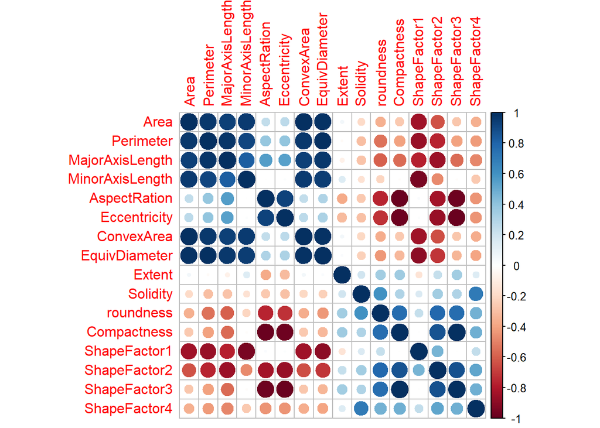

```r
if(length(strong_correlations) > 0) {
  beans_data[,strong_correlations] = NULL
}

corrplot(correlation_matrix)
```

```r
summary(beans_data)
```

```
##       Area          AspectRation      Eccentricity         Extent
##  Min.   :-1.1127   Min.   :-2.2636   Min.   :-5.7819   Min.   :-3.9607
##  1st Qu.:-0.5702   1st Qu.:-0.6119   1st Qu.:-0.3801   1st Qu.:-0.6336
##  Median :-0.2863   Median :-0.1302   Median : 0.1472   Median : 0.2063
##  Mean   : 0.0000   Mean   : 0.0000   Mean   : 0.0000   Mean   : 0.0000
##  3rd Qu.: 0.2825   3rd Qu.: 0.5021   3rd Qu.: 0.6475   3rd Qu.: 0.7562
##  Max.   : 6.8738   Max.   : 3.4339   Max.   : 1.7448   Max.   : 2.3726
##
##     Solidity          roundness        ShapeFactor1       ShapeFactor2
##  Min.   :-14.5689   Min.   :-6.4460   Min.   :-3.35603   Min.   :-1.93292
##  1st Qu.: -0.3160   1st Qu.:-0.6920   1st Qu.:-0.58838   1st Qu.:-0.94387
##  Median :  0.2446   Median : 0.1659   Median : 0.07231   Median :-0.03762
##  Mean   :  0.0000   Mean   : 0.0000   Mean   : 0.00000   Mean   : 0.00000
##  3rd Qu.:  0.6159   3rd Qu.: 0.7323   3rd Qu.: 0.62749   3rd Qu.: 0.76244
##  Max.   :  1.6167   Max.   : 1.9725   Max.   : 3.44642   Max.   : 3.27086
##
##   ShapeFactor4           Class
##  Min.   :-10.8500   BARBUNYA:1322
##  1st Qu.: -0.3116   BOMBAY  : 522
##  Median :  0.3029   CALI    :1630
##  Mean   :  0.0000   DERMASON:3546
##  3rd Qu.:  0.6457   HOROZ   :1928
##  Max.   :  1.0693   SEKER   :2027
##                     SIRA    :2636
```

Foi utilizada a função **findCorrelation** para obter os indices que denotam as colunas a serem removidas. A função os obtem examinando a correlação média de cada variável em um par com outra variável, e remove a mesma caso a correlação calculada esteja acima da taxa de corte definida. Neste exemplo, foi definida uma taxa de 0.95

Em alguns casos, variáveis com alta correlação acabam por não fornecer muita informação sobre o conjunto de dados estudados, ou seja, um par de varíaveis pode estar fornecendo a mesma informação. Entretanto, devemos tomar cuidado ao remover varíaveis, pois correlação não implica causalidade. De forma geral isso pode ser visto como um caso da Navalha de Occam, onde o modelo mais simples, ou seja, com menos variáveis, é preferido.

### 6 - Plote um gráfico boxplot ou de densidade por variável x classe (organize em 3 colunas). Discuta qual é a variável que teria maior poder de discriminação? Existe alguma classe que pode ser classificada mais facilmente? Justifique a sua escolha.

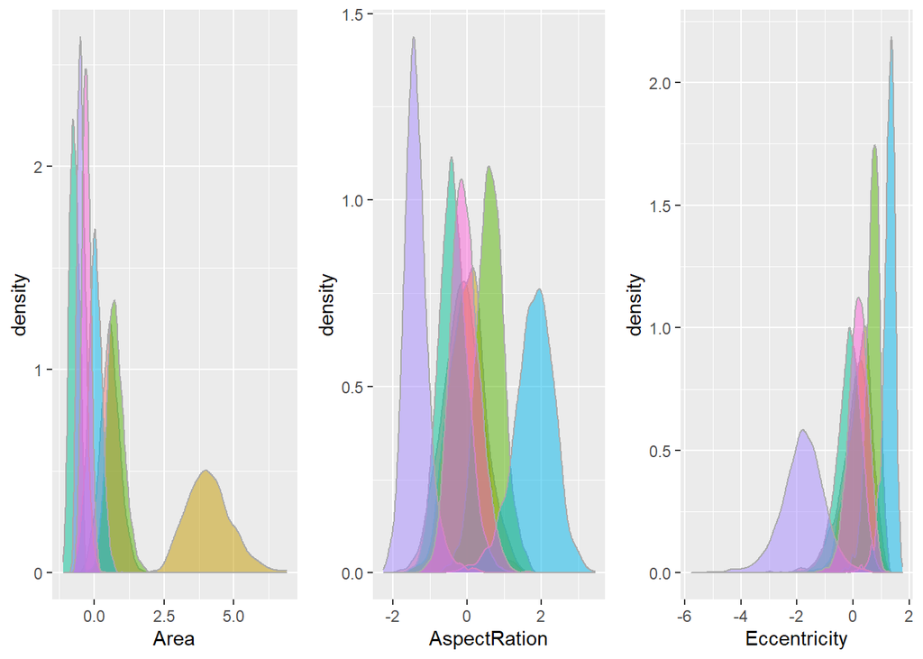

```r
library(gridExtra)
library(ggplot2)

p = list()
for(i in 1:3){
  p[[i]] = ggplot(beans_data, aes_string(x=names(beans_data)[i],fill="Class")) +
    geom_density(alpha=0.5,color="darkgray") +
    theme(legend.position="none",
          legend.title = element_blank())
}
do.call(grid.arrange,c(p,ncol=3))
```

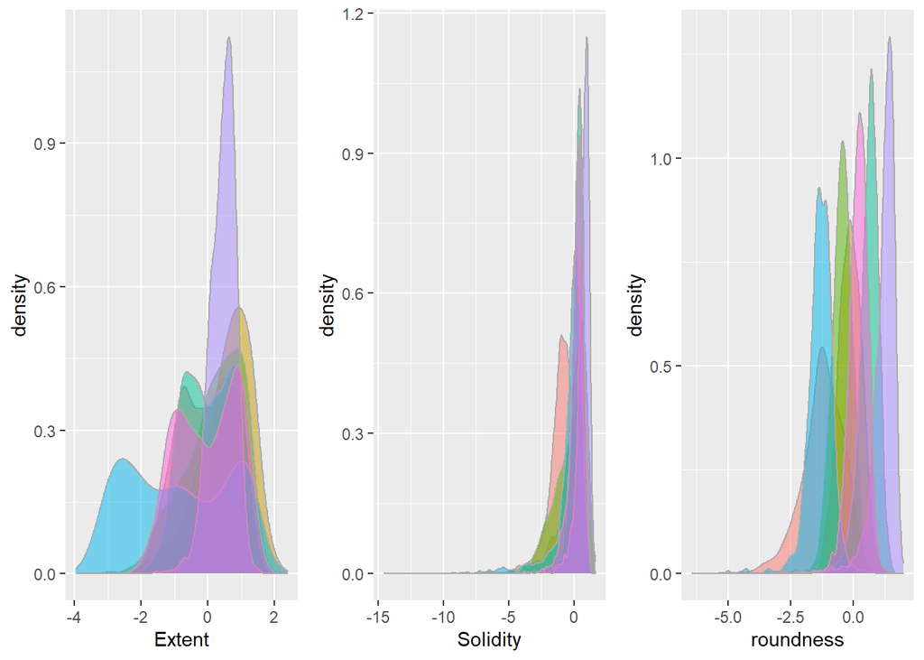

```r
p = list()
for(i in 4:6){
  p[[i - 3]] = ggplot(beans_data, aes_string(x=names(beans_data)[i],fill="Class")) +
    geom_density(alpha=0.5,color="darkgray") +
    theme(legend.position="none",
          legend.title = element_blank())
}

do.call(grid.arrange,c(p,ncol=3))
```

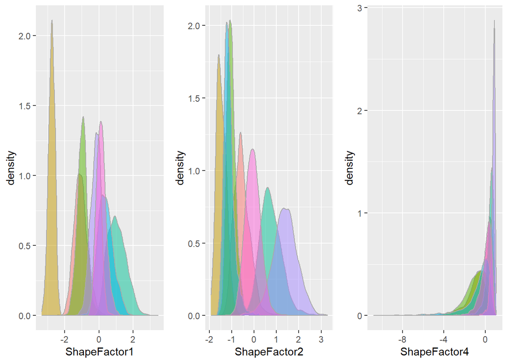

```r
p = list()
for(i in 7:9){
  p[[i - 6]] = ggplot(beans_data, aes_string(x=names(beans_data)[i],fill="Class")) +
    geom_density(alpha=0.5,color="darkgray") +
    theme(legend.position="none",
          legend.title = element_blank())
}
do.call(grid.arrange, c(p,ncol=3))
```

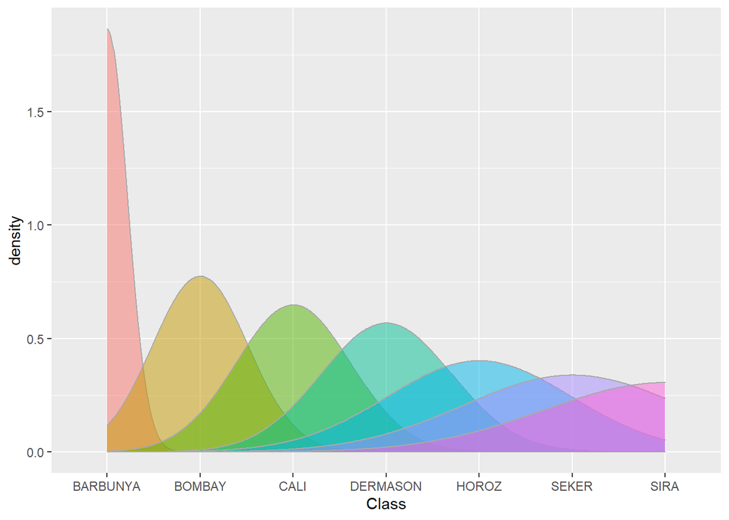

```r
p = list()
for(i in 10){
  p[[i-9]] = ggplot(beans_data, aes_string(x=names(beans_data)[i],fill="Class")) +
    geom_density(alpha=0.5,color="darkgray") +
    theme(legend.position="none",
          legend.title = element_blank())
}

do.call(grid.arrange,c(p,ncol=1))
```

Analizando os resultados, percebemos que a variável **ShapeFactor2** possui um alto poder de discriminação das classes, pois podemos notar a separação das médias das densidades. Essa discriminação também é vista nas variáveis **roudness** e **Area**, porém em um nível menor se comparadas a **ShapeFactor2**.

A classe que aprensenta uma melhor identificação é a **Bombay**, podendo ser comprovado analisando os gráficos das variavéis **ShapeFactor1**, **ShapeFactor2** e **Area**.

### 7 - Realize a projeção do dataset utilizando PCA. Explique as características dos componentes principais estimados. O que se pode explicar sobre os componentes principais utilizando o gráfico biplot. Apresente as características básicas (summary) dos dados.

```r
pca = prcomp(beans_data[,1:9], center=TRUE, scale=TRUE)

print(pca)
```

```
## Standard deviations (1, .., p=9):
## [1] 2.12485864 1.36328642 1.06948184 0.87439895 0.65139376 0.37872220 0.31485788
## [8] 0.21468953 0.07134114
##
## Rotation (n x k) = (9 x 9):
##                     PC1         PC2         PC3         PC4         PC5
## Area          0.2687358  0.54339558  0.16839081 -0.15104448 -0.10681438
## AspectRation  0.3986456 -0.27545683  0.26629405  0.16512712 -0.07773875
## Eccentricity  0.3984027 -0.25213789  0.25869684  0.22791903 -0.11349870
## Extent       -0.1664944  0.36206255  0.01620962  0.89862958  0.17676579
## Solidity     -0.2760129  0.00399956  0.71155341 -0.01337514 -0.32912884
## roundness    -0.4144215  0.10143629  0.04302433  0.01872927 -0.62652941
## ShapeFactor1 -0.1746708 -0.64327770 -0.07003302  0.24425730 -0.08177574
## ShapeFactor2 -0.4444371 -0.07872665 -0.25794238 -0.06119688  0.03737377
## ShapeFactor4 -0.3262747 -0.06223003  0.50393151 -0.16278825  0.65533985
##                      PC6         PC7         PC8          PC9
## Area          0.56768619  0.49173963 -0.06946579 -0.031971045
## AspectRation -0.16453582  0.33087845  0.69021695  0.219158401
## Eccentricity  0.36342714 -0.42215369 -0.35437221  0.458340439
## Extent       -0.02685893  0.03312511  0.01789772 -0.002697417
## Solidity     -0.37981951  0.21734822 -0.34275481  0.002001011
## roundness     0.32886813 -0.34934454  0.43906703 -0.015774839
## ShapeFactor1  0.40275449  0.37500136 -0.15407238 -0.397309565
## ShapeFactor2  0.07270366  0.36524809 -0.05650487  0.763358932
## ShapeFactor4  0.31296256 -0.16151327  0.23597299 -0.006293993
```

```r
summary(pca)
```

```
## Importance of components:
##                           PC1    PC2    PC3     PC4     PC5     PC6     PC7
## Standard deviation     2.1249 1.3633 1.0695 0.87440 0.65139 0.37872 0.31486
## Proportion of Variance 0.5017 0.2065 0.1271 0.08495 0.04715 0.01594 0.01102
## Cumulative Proportion  0.5017 0.7082 0.8353 0.92022 0.96736 0.98330 0.99431
##                            PC8     PC9
## Standard deviation     0.21469 0.07134
## Proportion of Variance 0.00512 0.00057
## Cumulative Proportion  0.99943 1.00000
```

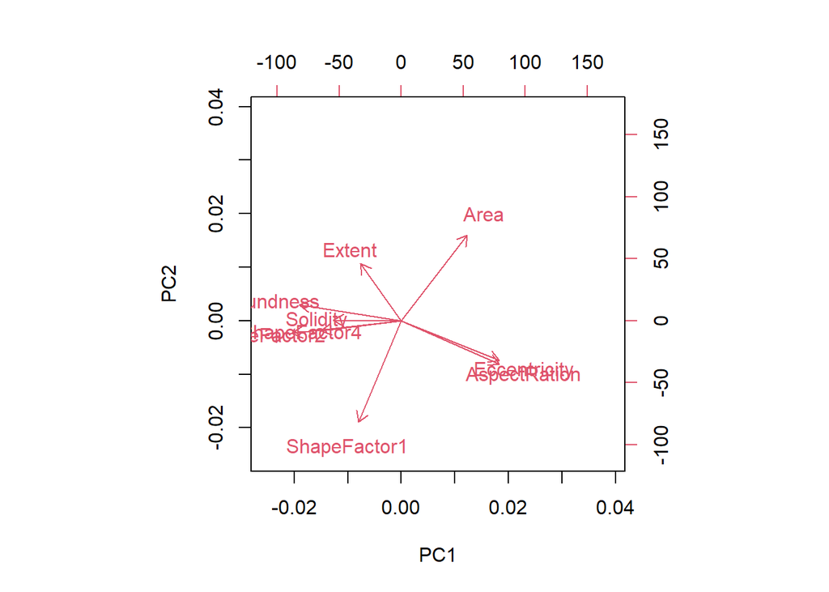

```r
explained_variance = pca$sdev^2 / sum(pca$sdev^2)

biplot(pca,xlabs = rep("", nrow(beans_data)))
```

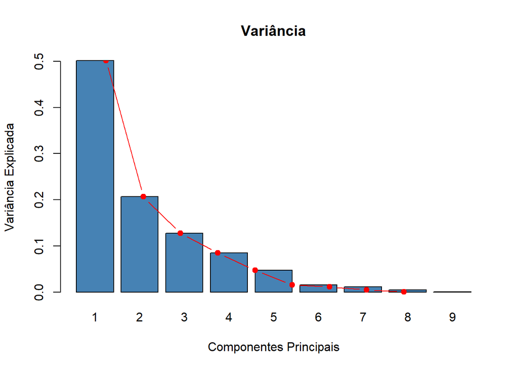

```r
barplot (
  explained_variance,
  names.arg=1:9,
  main = "Variância",
  xlab = "Componentes Principais",
  ylab = "Variância Explicada",
  col ="steelblue"
)

lines (
  x = 1:9,
  explained_variance,
  type="b",
  pch=19,
  col = "red"
)
```

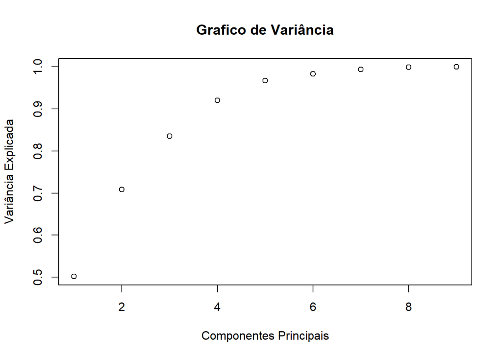

```r
cumpro <- cumsum(pca$sdev^2 / sum(pca$sdev^2))
plot(cumpro[1:9], xlab = "Componentes Principais", ylab = "Variância Explicada", main = "Gŕafico de Variância")
```

Interpretando o gráfico biplot resultante e as variâncias das variáveis, temos que as variáveis Area, AspectRatio e Eccentricity influenciam positivamente a proporção da variância de PC1, enquanto as demais afetam negativamente. Podemos visualizar isso analisando os vetores do gráfico biplot, onde notamos que as variáveis que afetam positivamente estão alinhadas com o eixo de PC1, apontando em direção positiva, enquanto as que afetam negativamente estão apontando para a direção negativa. Para PC2, temos que as variáveis Area, Extent, Solidity e roundness a afetam positivamente.

Nota-se que a variável Area afeta positivamente ambos PC1 e PC2. Podemos ver essa relação no gráfico, onde Area aponta em direção positva a PC1 e PC2.

Temos também que PC1 explica 50% da varíancia do conjunto.

### 8 - Analise o dataset projetado com o auxílio do gráfico de boxplot por classe (igual ao do item 6). Compare com o resultado do item 6. Se quiser, pode gerar um gráfico de espalhamento para auxiliar na explicação.

```r
#thresh = 1.0 não reduz dimensionalidade
pca_params = preProcess(beans_data, method=c("center", "scale", "pca"), thresh = 1.0)

projected_data = predict(pca_params, beans_data)
summary(projected_data)
```

```
##       Class           PC1               PC2               PC3
##  BARBUNYA:1322   Min.   :-5.7202   Min.   :-4.0561   Min.   :-16.5782
##  BOMBAY  : 522   1st Qu.:-1.5794   1st Qu.:-0.9008   1st Qu.: -0.4407
##  CALI    :1630   Median :-0.1788   Median :-0.1087   Median :  0.0879
##  DERMASON:3546   Mean   : 0.0000   Mean   : 0.0000   Mean   :  0.0000
##  HOROZ   :1928   3rd Qu.: 1.7606   3rd Qu.: 0.7780   3rd Qu.:  0.5912
##  SEKER   :2027   Max.   : 8.2338   Max.   : 6.2384   Max.   :  2.9224
##  SIRA    :2636
##       PC4                PC5                PC6                PC7
##  Min.   :-2.78096   Min.   :-3.95452   Min.   :-1.51312   Min.   :-0.82949
##  1st Qu.:-0.62998   1st Qu.:-0.33976   1st Qu.:-0.24599   1st Qu.:-0.23594
##  Median :-0.08214   Median :-0.09421   Median :-0.03586   Median :-0.05875
##  Mean   : 0.00000   Mean   : 0.00000   Mean   : 0.00000   Mean   : 0.00000
##  3rd Qu.: 0.65405   3rd Qu.: 0.20517   3rd Qu.: 0.20287   3rd Qu.: 0.18671
##  Max.   : 3.12374   Max.   : 4.73138   Max.   : 2.83195   Max.   : 1.85861
##
##       PC8                PC9
##  Min.   :-1.44302   Min.   :-0.68321
##  1st Qu.:-0.12268   1st Qu.:-0.03121
##  Median :-0.00891   Median :-0.00120
##  Mean   : 0.00000   Mean   : 0.00000
##  3rd Qu.: 0.12085   3rd Qu.: 0.04086
##  Max.   : 1.11517   Max.   : 0.36078
##
```

```r
names(projected_data)
```

```
##  [1] "Class" "PC1"   "PC2"   "PC3"   "PC4"   "PC5"   "PC6"   "PC7"   "PC8"
## [10] "PC9"
```

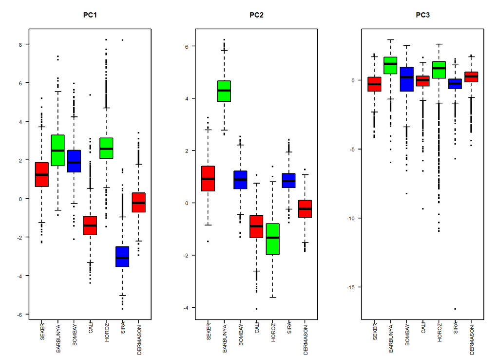

```r
colors=c("red", "green", "blue")

par(mfrow=c(1,3), cex=0.5)
for(i in 2:4){
  plot <- boxplot(projected_data[,i] ~ projected_data$Class,
                  col=colors, xlab = "",
                  ylab="",
                  main = names(projected_data)[i],
                  xaxt = "n",
                  yaxt = "n")
  axis(side = 1, labels = FALSE)
  axis(side = 2, las = 2, cex.axis = 0.9, font =20)
  text(x = 1:num_classes,
       labels = classes,
       par("usr")[3],
       xpd = T,
       srt = 90,
       adj = 1.2,
       cex = 0.9)
}
```

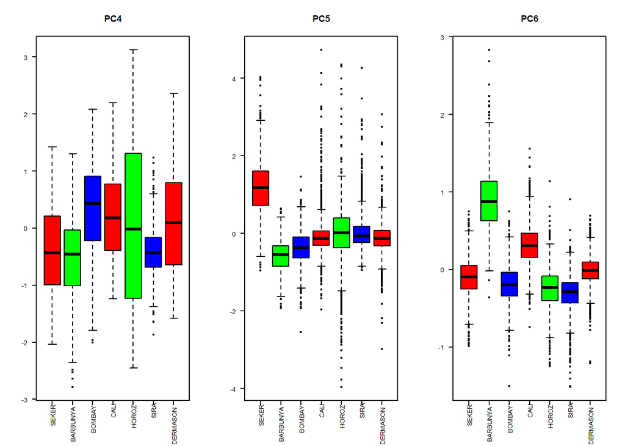

```r
par(mfrow=c(1,3), cex=0.5)
for(i in 5:7){
  plot <- boxplot(projected_data[,i] ~ projected_data$Class,
                  col=colors, xlab = "",
                  ylab="",
                  main = names(projected_data)[i],
                  xaxt = "n",
                  yaxt = "n")
  axis(side = 1, labels = FALSE)
  axis(side = 2, las = 2, cex.axis = 0.9, font =20)
  text(x = 1:num_classes,
       labels = classes,
       par("usr")[3],
       xpd = T,
       srt = 90,
       adj = 1.2,
       cex = 0.9)
}
```

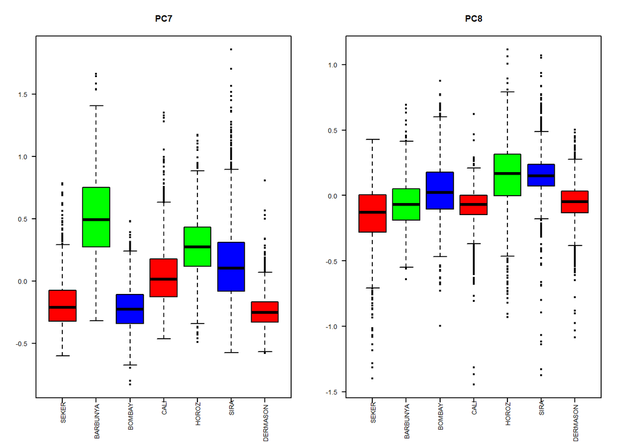

```r
par(mfrow=c(1,2), cex=0.5)
for(i in 8:9){
  plot <- boxplot(projected_data[,i] ~ projected_data$Class,
                  col=colors, xlab = "",
                  ylab="",
                  main = names(projected_data)[i],
                  xaxt = "n",
                  yaxt = "n")
  axis(side = 1, labels = FALSE)
  axis(side = 2, las = 2, cex.axis = 0.9, font =20)
  text(x = 1:num_classes,
       labels = classes,
       par("usr")[3],
       xpd = T,
       srt = 90,
       adj = 1.2,
       cex = 0.9)
}
```

### 9 - É possível reduzir a dimensionalidade dos dados? Explique como!

Sim, é possível reduzir a dimensionalidade dos dados. Podemos fazer isso durante a transformação dos dados com a função **preProcess**, estipulando um valor de corte para a porcentagem cumulativa de variância da componente principal, assim, serão eliminadas todas as dimensões dos dados transformados com porcentagem de variância cumulativa acima do valor de corte.

```r
reduced_pca_params = preProcess(beans_data, method=c("center", "scale", "pca"), thresh = .95)

reduced_projected_data = predict(reduced_pca_params, beans_data)
summary(reduced_projected_data)
```

```
##       Class           PC1               PC2               PC3
##  BARBUNYA:1322   Min.   :-5.7202   Min.   :-4.0561   Min.   :-16.5782
##  BOMBAY  : 522   1st Qu.:-1.5794   1st Qu.:-0.9008   1st Qu.: -0.4407
##  CALI    :1630   Median :-0.1788   Median :-0.1087   Median :  0.0879
##  DERMASON:3546   Mean   : 0.0000   Mean   : 0.0000   Mean   :  0.0000
##  HOROZ   :1928   3rd Qu.: 1.7606   3rd Qu.: 0.7780   3rd Qu.:  0.5912
##  SEKER   :2027   Max.   : 8.2338   Max.   : 6.2384   Max.   :  2.9224
##  SIRA    :2636
##       PC4                PC5
##  Min.   :-2.78096   Min.   :-3.95452
##  1st Qu.:-0.62998   1st Qu.:-0.33976
##  Median :-0.08214   Median :-0.09421
##  Mean   : 0.00000   Mean   : 0.00000
##  3rd Qu.: 0.65405   3rd Qu.: 0.20517
##  Max.   : 3.12374   Max.   : 4.73138
##
```

### 10 - Analise o dataset reduzido com o auxílio do gráfico de boxplot por classe (igual ao do item 6). . Compare com o resultado do item 6 e do item 8. Se quiser, pode gerar um gráfico de espalhamento para auxiliar na explicação.

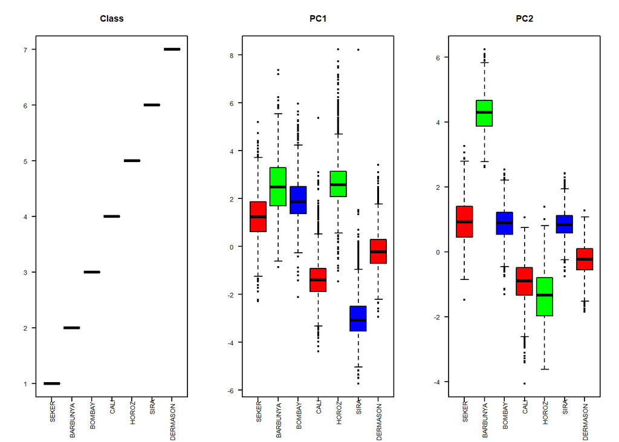

```r
colors=c("red", "green", "blue")

par(mfrow=c(1,3), cex=0.5)
for(i in 1:3){
  plot <- boxplot(reduced_projected_data[,i] ~ reduced_projected_data$Class,
                  col=colors, xlab = "",
                  ylab="",
                  main = names(reduced_projected_data)[i],
                  xaxt = "n",
                  yaxt = "n")
  axis(side = 1, labels = FALSE)
  axis(side = 2, las = 2, cex.axis = 0.9, font =20)
  text(x = 1:num_classes,
       labels = classes,
       par("usr")[3],
       xpd = T,
       srt = 90,
       adj = 1.2,
       cex = 0.9)
}
```

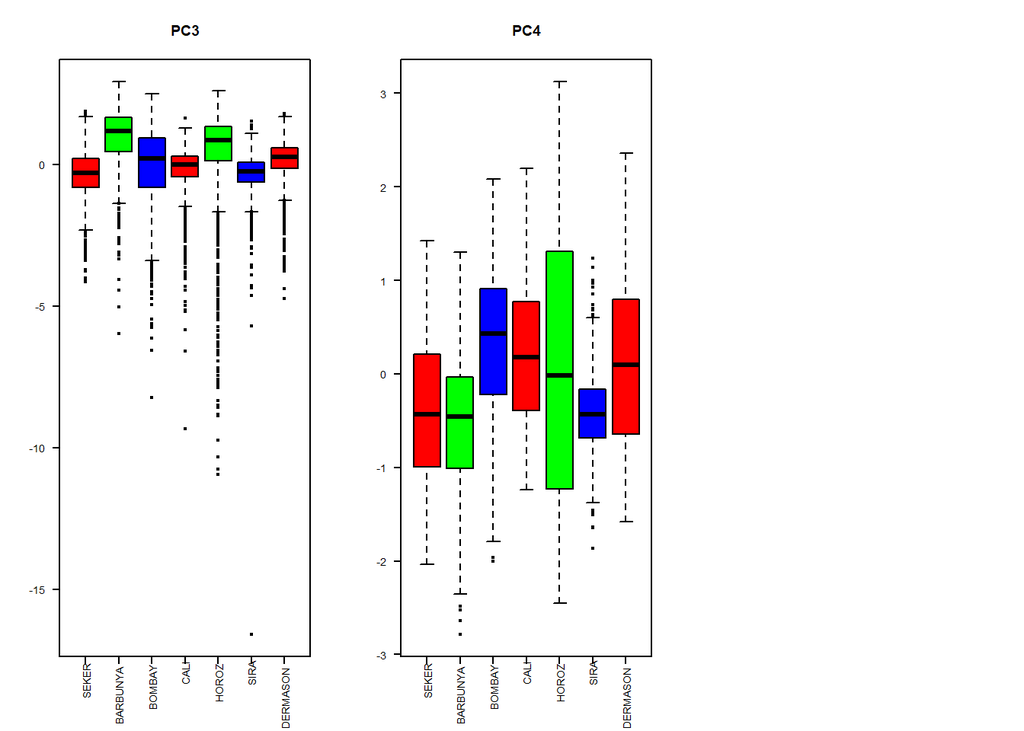

```r
par(mfrow=c(1,3), cex=0.5)
for(i in 4:5){
  plot <- boxplot(reduced_projected_data[,i] ~ reduced_projected_data$Class,
                  col=colors, xlab = "",
                  ylab="",
                  main = names(reduced_projected_data)[i],
                  xaxt = "n",
                  yaxt = "n")
  axis(side = 1, labels = FALSE)
  axis(side = 2, las = 2, cex.axis = 0.9, font =20)
  text(x = 1:num_classes,
       labels = classes,
       par("usr")[3],
       xpd = T,
       srt = 90,
       adj = 1.2,
       cex = 0.9)
}
```